# Interpretabilidad

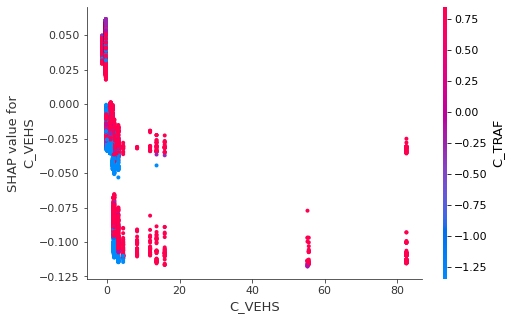

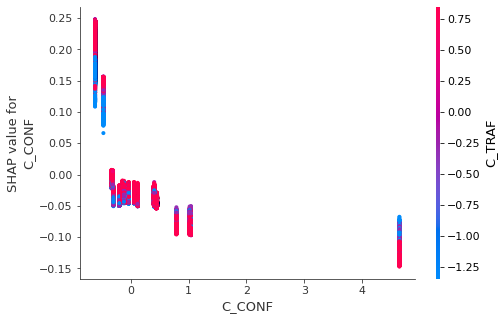

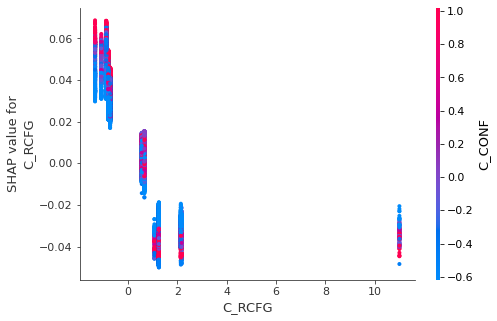

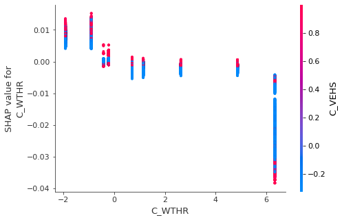

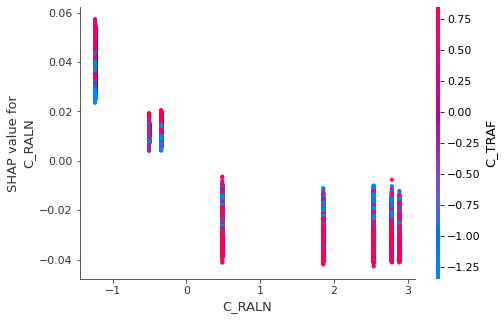

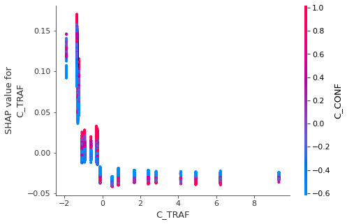

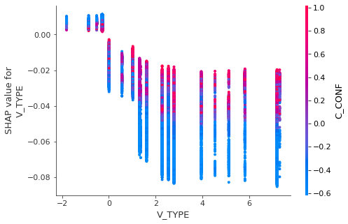

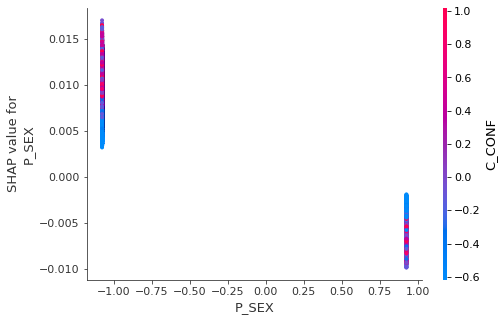

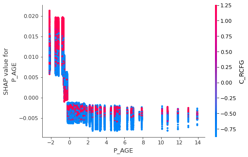

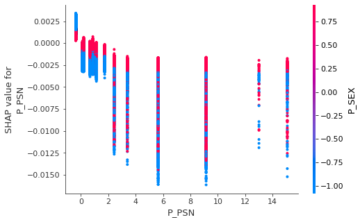

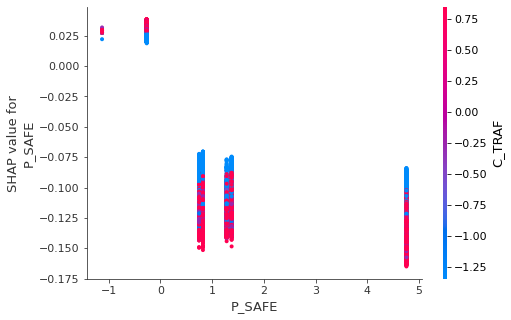

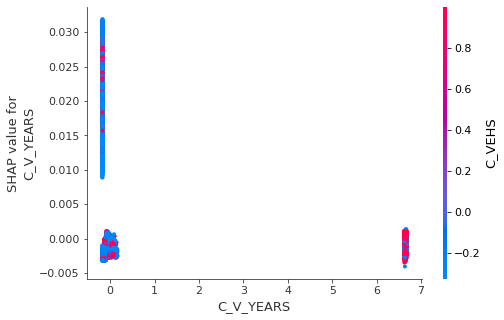

[6 more figures not shown]

```python
for name in collision_xtrain_l.columns:
    shap.dependence_plot(name, shap_values[0], collision_xtest_l, display_features=collision_xtest_l)
```

## Conclusión

En conclusión, se ha generado un modelo de ML óptimo que permite predecir la variable objetivo dado una serie de variables relacionadas con la causalidad de los accidente de tráfico.

Se ha optado por elegir un modelo Random Forest, que obtiene los mejores resultados para modelos de clasificación como el que se ha propuesto y en el que se opera con un número elevado de variables. De la misma forma, la selección de este modelo permite conocer y establecer un orden de importancia de las variables del conjunto.

Se observan evidencias del buen ajuste del modelo al relacionar la interpretación que se hace mediante valores SHAP y EDA, donde las variables asociadas a mayores tasas de mortalidad coinciden con aquellas variables que, de forma interna al modelo, arrastran al modelo a predecir un fallecimiento.